# 5_Model made better

Simon

2024-01-09

# I. Load data

In this section, I load data for the baseline calibration using the linear and linear quadratic cost models.

| params | value | concept | units |
| --- | --- | --- | --- |
| alpha | 1625836.98 | Demand model : intercept | USD |
| beta | 1563.75 | Demand model : coefficient | USD/metric ton of biomass |
| r | 0.20 | Intrinsic growth rate | unitless |
| k | 20226.00 | Carrying capacity (in metric tons) | % of biomass/vessel trip |
| sigma | 0.00 | Catchability | metric tons of biomass |
| W_mid | 2.18 | Parameter cost (MC = Avg) at historical value - middle | USD |
| W_low | 1.32 | Parameter cost (MC = Avg) at historical value - low | USD |
| W_high | 3.75 | Parameter cost (MC = Avg) at historical value - high | USD |
| avg_cost | 3.75 | Average cost per vessel trip | USD |
| age | 4.50 | Age of farmed totoaba | Years |
| gamma | 1407.38 | Substitutability | Unitless |
| v | 67034.45 | Unit cost of farming | USD/metric ton of biomass |
| c | 0.00 | Unit cost of trading | USD/ metric ton of biomass |

## II. Define functions

Define function where variable is either `x` i.e population stock, or `s` i.e price paid to poachers. All the parameters take default values specified in the global environment.

- `growth(x, ...)` : logistic growth function, yields growth of population (in metric tons)
- `pt_harvest(x,...)` : harvest (in metric tons) when trader is price taker
- `monop_harvest(x, ...)`: harvest (in metric tons) when trader is a monopolist
- `monop_harvest_lq(x, ...)`: harvest (in metric tons) when trader is a monopolist and cost structure is linear quadratic
- `cournot_harvest(x, ...)`, `bertrand_harvest(x, ...)`: harvest (in metric tons) when trader and farmer compete in *Cournot*, i.e, set quantities strategically, and *Bertrand*, i.e, set prices strategically.
- `cournot_harvest_lq(x, ...)`, `bertrand_harvest_lq(x, ...)` : harvest (in metric tons) when trader and farmer compete in *Cournot* i.e, set quantities strategically, and *Bertrand* i.e, set prices strategically and cost structure is linear quadratic
- `price_poachers_cournot(x, ...)`, `price_poachers_bertrand(x, ...)`: price paid to poachers (in USD/metric tons) when trader and farmer compete in *Cournot* and *Bertrand*
- `cournot_farmed(s, ...)`, `bertrand_farmed(s, ...)`: quantity farmed (in metric tons) when trader and farmer compete in *Cournot* and *Bertrand*

## III. Generate results

Generate results saved at `~/data/outputs/results_all_models.csv` :

- Set cost variables using `W_lq`: each row corresponds to a cost parameter $W$, $W_1$ and $W_2$

### Graph outputs :

First, illustrate the new equilibria with the same $W$ value and the middle point solution for $W_1$ and $W_2$ in the linear quadratic cost of effort specification.

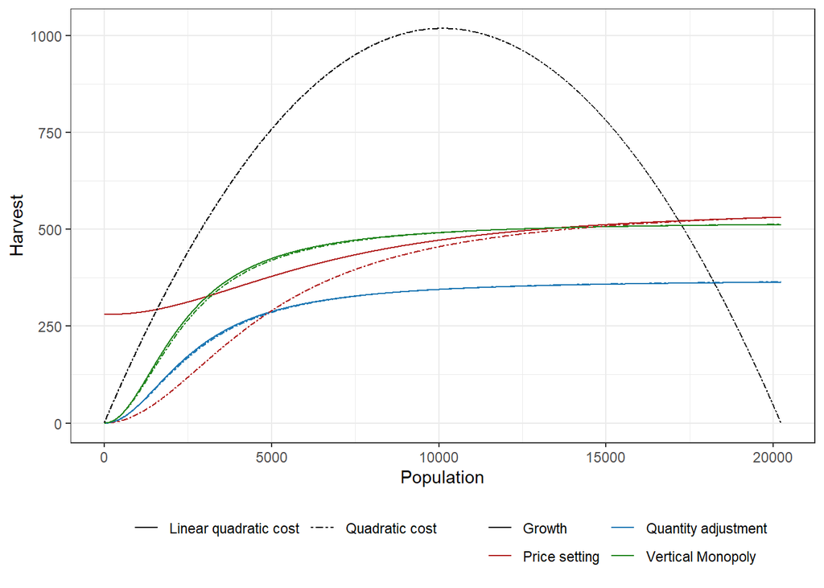

To understand the impact of different $W_1$ & $W_2$ divides :

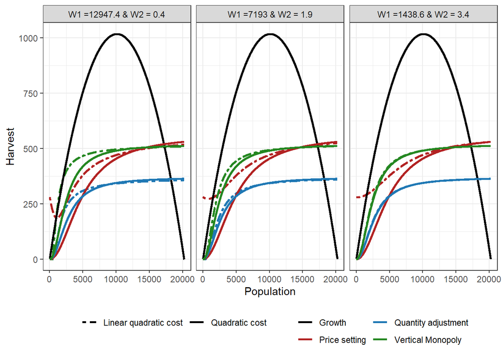

Clearly, the choice of $W_1$ and $W_2$ is important with respect to the anticipated equilibrium in the *vertical monopoly* case : with a linear-quadratic cost function, we no longer can say the monopoly will achieve a *healthy* steady state population. The results in the **post intervention** world are robust to the cost specification, and guarantee population increases in the *quantity adjustment* scenario, while population may marginally diminish in the *price setting* scenario.

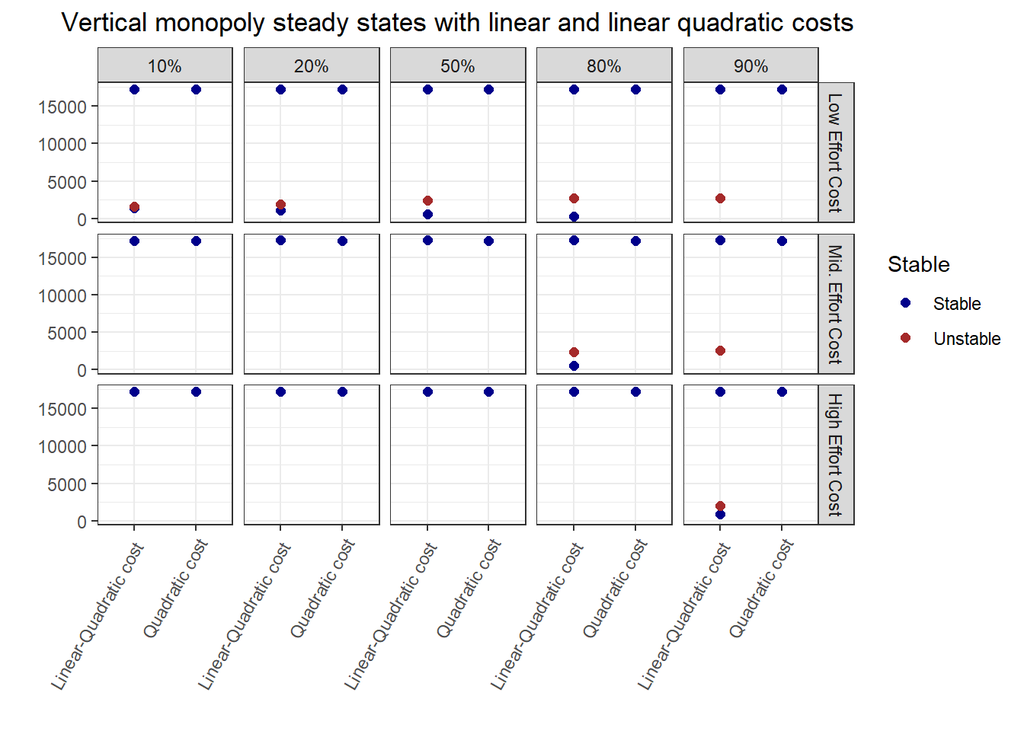

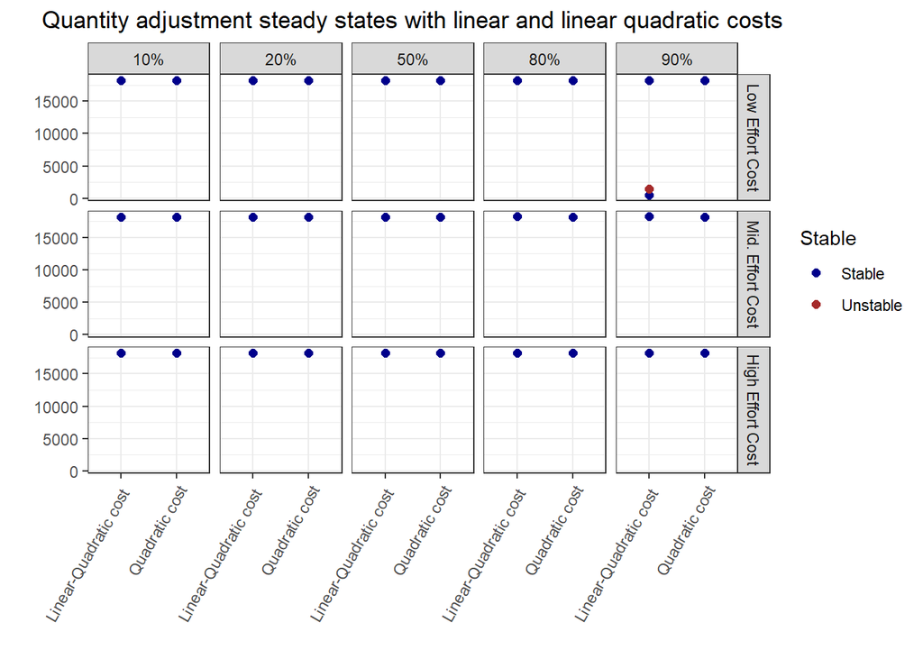

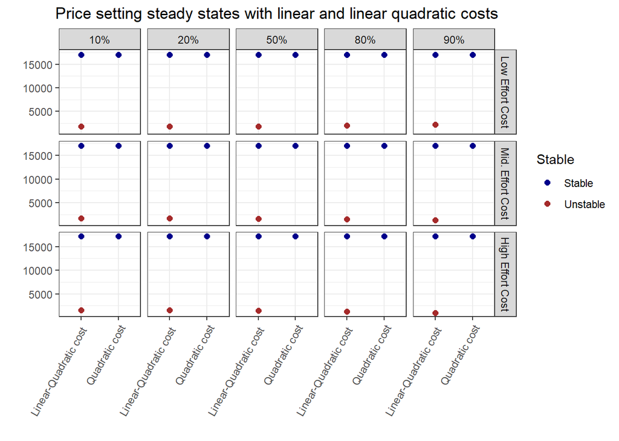

Define bio-economic performance by combining population variables (stock and harvest) with price and profit data from economic model.

| Scenario | Poached harvest (in mt) | Farmed harvest (in mt) | Steady state population (in mt) | Retail price (in USD/ton of buche) | Retail price of 500g buche (in USD) | Price paid to poacher (in USD/ton of buche) | Poacher price of 500g buche (in USD) | Illegal profit (in million USD) | Farming profit (in million USD) | Fishing profit (in million USD) | Aggregate profit (in million USD) | Aggregate profit change (in million USD) | Farming profit change (in million USD) | Illegal profit change (in million USD) | Fishing profit change (in million USD) | Variation in ss. pop. | Poaching change (%) |
| --- | --- | --- | --- | --- | --- | --- | --- | --- | --- | --- | --- | --- | --- | --- | --- | --- | --- |
| Vertical Monopoly | 513.83 | 0.00 | 17229.5 | 822338.8 | 21134.108 | 18840.66 | 484.2050 | 412.86 | 0.00 | 4.84 | 417.70 | 0.00 | 0.00 | 0.00 | 0.00 | 0% | 0% |
| Quantity adjustment | 365.80 | 333.81 | 18207.5 | 584026.4 | 15009.479 | 12010.58 | 308.6720 | 209.24 | 174.25 | 2.20 | 385.68 | -32.01 | 174.25 | -203.62 | -2.64 | 5.68% | -28.81% |
| Price setting | 535.99 | 432.31 | 17071.5 | 179266.8 | 4607.156 | 20018.62 | 514.4784 | 85.35 | 55.53 | 5.36 | 146.25 | -271.45 | 55.53 | -327.50 | 0.52 | -0.92% | 4.31% |
| Vertical Monopoly - LQ cost | 512.96 | 0.00 | 17235.5 | 823689.5 | 21168.821 | 21542.05 | 553.6307 | 411.47 | 0.00 | 2.41 | 413.88 | -3.82 | 0.00 | -1.39 | -2.43 | 0.03% | -0.17% |
| Quantity adjustment - LQ cost | 363.62 | 334.79 | 18221.0 | 586054.7 | 15061.607 | 17447.82 | 448.4089 | 206.76 | 175.27 | 1.08 | 383.11 | -34.59 | 175.27 | -206.10 | -3.76 | 5.75% | -29.23% |
| Price setting - LQ cost | 541.43 | 433.90 | 17086.5 | 168510.5 | 4330.719 | 21694.73 | 557.5546 | 79.49 | 51.33 | 3.15 | 133.96 | -283.73 | 51.33 | -333.37 | -1.69 | -0.83% | 5.37% |